# Competing Risks2026 Practicals II

Author

Ronald Geskus

Published

### Data

In the competing risks practical, we only use information on relapse and death. We investigate the role of the EBMT risk score, but we correct for age as a possible confounder. The EBMT score is a combination of donor-recipient match and age of the recipient, among other things. It divides patients into three risk groups. The event time and event status are in the columns `srv` and `srvstat`.

- We again load the packages and the data

```r
library(mstate)
library(ggsurvfit)
library(survminer)
data(ebmt1)
```

### 4. Some data preparation for competing risks analyses

- Add three more columns to the `ebmt1` data set, *time to first event*, and *type of first event* both as numeric and factor variable. As factor variable, we need to make `Event-free` the first level because it represents censoring. We also change the unit of time into years.

```r
ebmt1 <- within(ebmt1,{
  time <- pmin(srv,rel)/365.25
  stat <-  ifelse(rel<srv,relstat,srvstat*2) #relapse=1, death=2
  type <- factor(stat,
               labels=c("Event-free","Relapse","Death"))
})
head(ebmt1)
```

```
  patid  srv srvstat  rel relstat      yrel age       score       type stat      time
1     1 1610       0 1610       0      <NA>  28 Medium risk Event-free    0 4.4079398
2     2  961       1  165       1 1997-1999  33 Medium risk    Relapse    1 0.4517454
3     3 1508       0 1508       0      <NA>  38 Medium risk Event-free    0 4.1286790
4     4 1376       0 1376       0      <NA>  15 Medium risk Event-free    0 3.7672827
5     5 1585       0  133       1 1997-1999  26 Medium risk    Relapse    1 0.3641342
6     6  190       1   63       1 1997-1999  22 Medium risk    Relapse    1 0.1724846
```

### 5. Estimation of cause-specific cumulative incidence (Aalen-Johansen estimator)

- Compute the Aalen-Johansen estimator of the cause-specific cumulative incicence and summarize the estimate at 1 and 5 years with 95% confidence intervals.

```r
cuminc <- survfit(Surv(time,type)~1, ebmt1)
summ <- summary(cuminc, times=c(1,5))
summ
```

```
Call: survfit(formula = Surv(time, type) ~ 1, data = ebmt1)

 time n.risk n.event Pr((s0)) Pr(Relapse) Pr(Death)
    1   1012     897    0.538       0.156     0.306
    5    198     233    0.378       0.258     0.363
```

```r
summ$lower
```

```
          (s0)   Relapse     Death
[1,] 0.5159829 0.1408540 0.2861585
[2,] 0.3547038 0.2373977 0.3415529
```

```r
summ$upper
```

```
          (s0)   Relapse     Death
[1,] 0.5604699 0.1732993 0.3272103
[2,] 0.4036558 0.2810544 0.3864437
```

### 6. Some plots

- Plot the estimates, with 95% confidence intervals, using the overlaid display format. Add a legend that links the curves to the two end points.

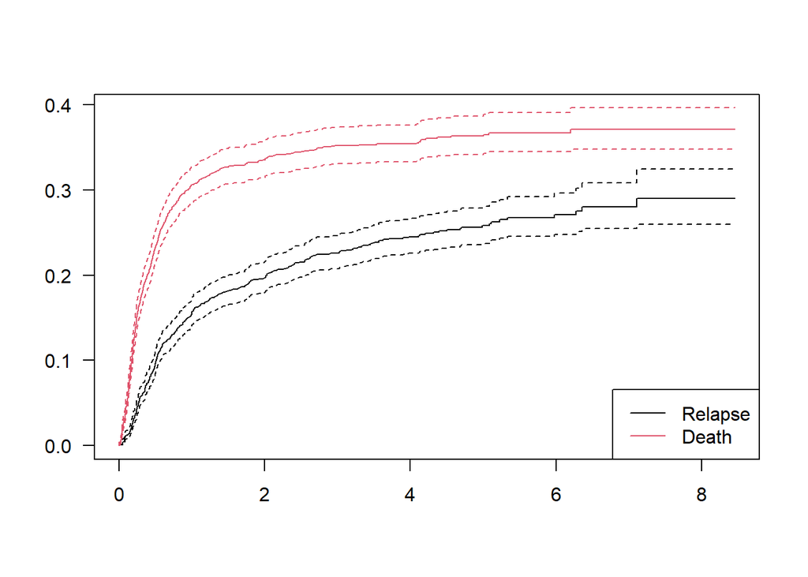

```r
par(las=1) # labels along y-axis rotated in rest of R session
plot(cuminc, conf.int=TRUE, col = c(1,2))
legend("bottomright", legend = c("Relapse", "Death"), lwd = 1, col = c(1,2))
```

In `ggsurvfit`, the legend is generated automatically.

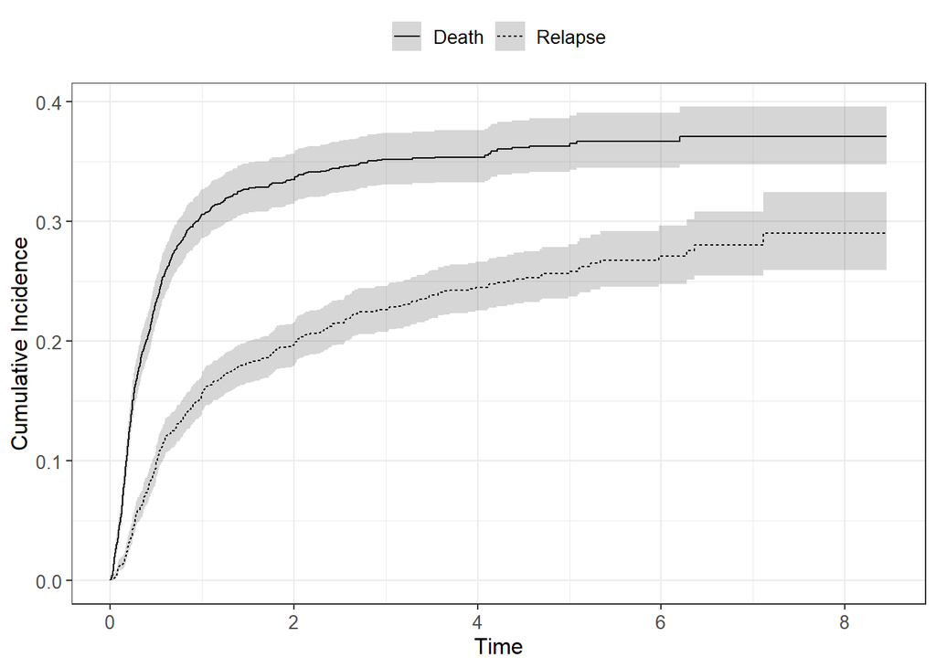

```r
ggcuminc(cuminc, outcome=c("Relapse","Death")) +
    add_confidence_interval() + theme(legend.position = "top")
```

In `survminer`, for the overlaid display we need to compute the estimate via the *cmprsk* package.

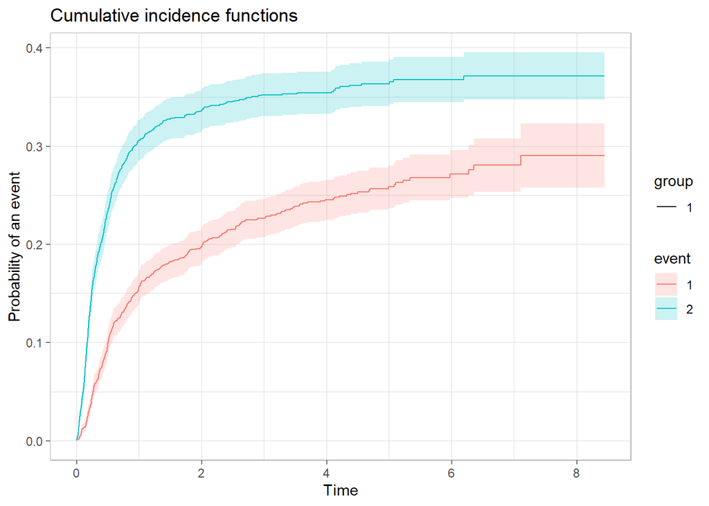

```r
library(cmprsk)
cuminc2 <- with(ebmt1, cuminc(time,stat))
ggcompetingrisks(cuminc2, conf.int=TRUE, multiple_panels=FALSE, ggtheme = theme_light())
```

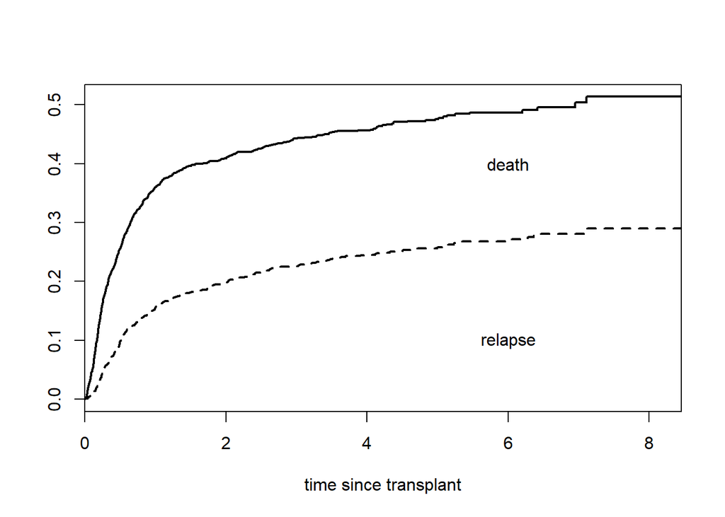

```r
KM.overall <- survfit(Surv(srv/365.25,srvstat)~1, data=ebmt1)
plot(KM.overall, lwd=2, lty=1, xaxs="i", conf.int=FALSE,
     fun="event", xlab="time since transplant")
lines(cuminc[2],  lwd=2, lty=2, conf.int=FALSE)
  text(c(6,6),c(0.1,0.4),c("relapse","death"))
```

The stacked format is the default in `survminer`.

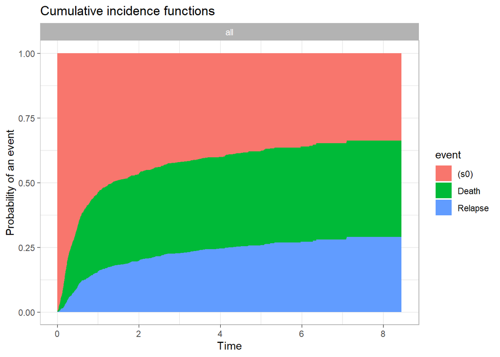

```r
ggcompetingrisks(cuminc,  ggtheme = theme_light())
```

- Plot the estimates using the alternate display format, with 95% confidence intervals.

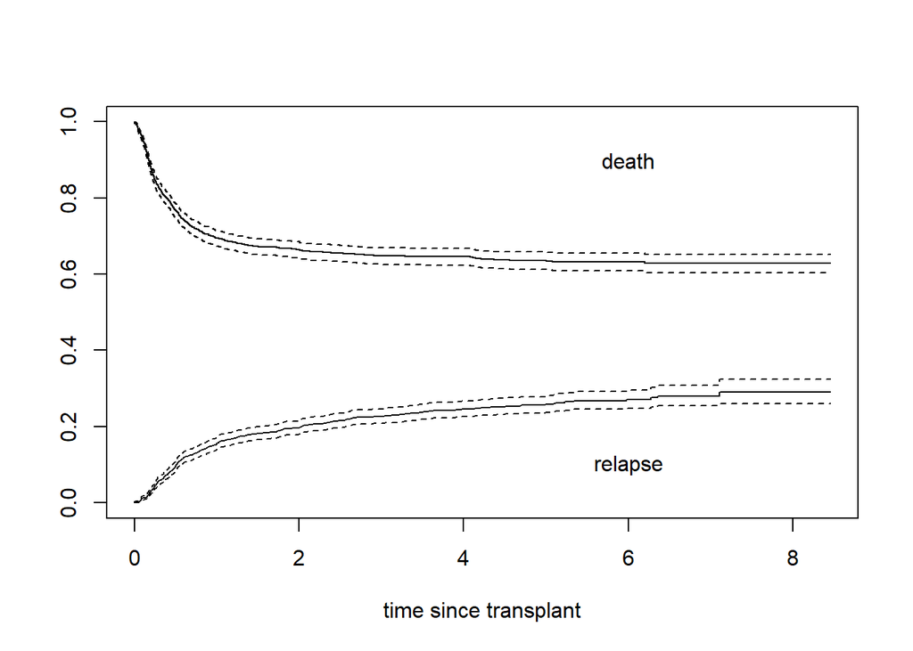

```r
plot(cuminc[3], fun=\(x) 1-x, xlab="time since transplant", ylim=c(0,1))
lines(cuminc[2])
text(c(6,6),c(0.1,0.9),c("relapse","death"))
```

### 7. Regression on the cause-specific hazards

- Fit a proportional hazards model for relapse and survival as competing risks. A proportional hazards model on the relapse-specific hazard can be fitted by censoring individuals when they experience the competing event. Only the individuals with `stat` equal to 1 had a relapse. Similarly for death: only individuals with `stat` equal to 2 died without relapse; individuals that had a relapse are censored.

```r
fit.rel <- coxph(Surv(time,stat==1)~score, data=ebmt1)
fit.death <- coxph(Surv(time,stat==2)~score, data=ebmt1)
fit.rel
```

```
Call:
coxph(formula = Surv(time, stat == 1) ~ score, data = ebmt1)

                   coef exp(coef) se(coef)     z        p
scoreMedium risk 0.4319    1.5401   0.1255 3.440 0.000581
scoreHigh risk   1.0855    2.9609   0.1829 5.934 2.95e-09

Likelihood ratio test=33.03  on 2 df, p=6.73e-08
n= 1977, number of events= 456
```

```r
fit.death
```

```
Call:
coxph(formula = Surv(time, stat == 2) ~ score, data = ebmt1)

                   coef exp(coef) se(coef)     z        p
scoreMedium risk 0.6393    1.8951   0.1133 5.642 1.69e-08
scoreHigh risk   1.1782    3.2487   0.1534 7.680 1.59e-14

Likelihood ratio test=62.91  on 2 df, p=2.185e-14
n= 1977, number of events= 685
```

A higher value of EBMT risk score increases both cause-specific hazards in a fairly similar way. We would like to perform a test for the difference in hazard ratio for the two competing risks. For this we need to use a stacked data set.